# Lab-04-Dodson

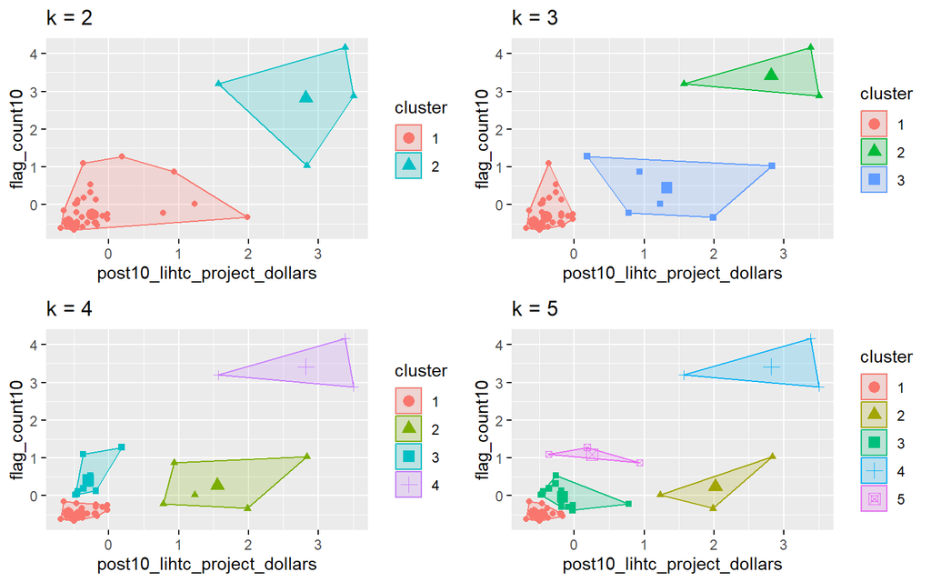

```r
# plots to compare
p_k2_lihtc_div <- factoextra::fviz_cluster(k2_lihtc_div, geom = "point", data = svi_divisional_lihtc_cluster) + ggtitle("k = 2")

p_k3_lihtc_div <- factoextra::fviz_cluster(k3_lihtc_div, geom = "point", data = svi_divisional_lihtc_cluster) + ggtitle("k = 3")

p_k4_lihtc_div <- factoextra::fviz_cluster(k4_lihtc_div, geom = "point",  data = svi_divisional_lihtc_cluster) + ggtitle("k = 4")

p_k5_lihtc_div <- factoextra::fviz_cluster(k5_lihtc_div, geom = "point",  data = svi_divisional_lihtc_cluster) + ggtitle("k = 5")

grid.arrange(p_k2_lihtc_div, p_k3_lihtc_div, p_k4_lihtc_div, p_k5_lihtc_div, nrow = 2)
```

```
##  [1]  1  2  3  4  5  6  7  8  9 10 11 12 13 14 15
## [1] 1
## [1] 2
## [1] 3
## [1] 4
## [1] 5
## [1] 6
## [1] 7
## [1] 8
## [1] 9
## [1] 10
## [1] 11
## [1] 12
## [1] 13
## [1] 14
## [1] 15
```

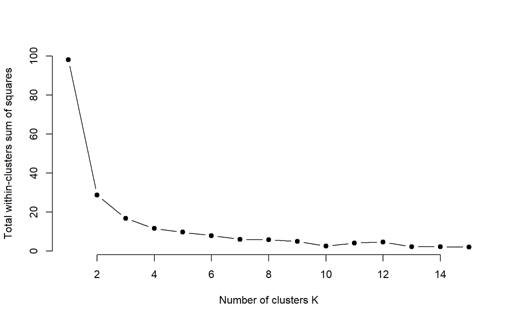

```r
elbow_plot(svi_divisional_lihtc_cluster)
```

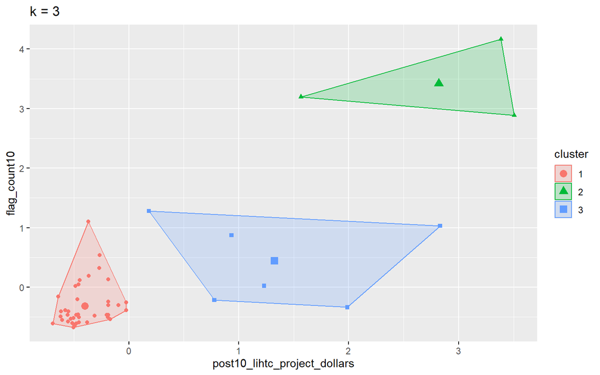

```r
p_k3_lihtc_div <- factoextra::fviz_cluster(k3_lihtc_div, geom = "point", data = svi_divisional_lihtc_cluster) + ggtitle("k = 3")

p_k3_lihtc_div
```

Once again, it appears that our data would be better represented as three clusters.

```r
svi_divisional_lihtc_cluster_label <- as.data.frame(svi_divisional_lihtc_cluster) %>%
                                  rownames_to_column(var = "county_name") %>%
                                  as_tibble() %>%
                                  mutate(cluster = k3_lihtc_div$cluster) %>%
                                  select(county_name, cluster)

svi_divisional_county_lihtc_projects2 <- left_join(svi_divisional_county_lihtc_projects, svi_divisional_lihtc_cluster_label, join_by(county_name == county_name))

# View county counts in each cluster
table(svi_divisional_county_lihtc_projects2$cluster)
```

```
##
##  1  2  3
## 41  3  6
```

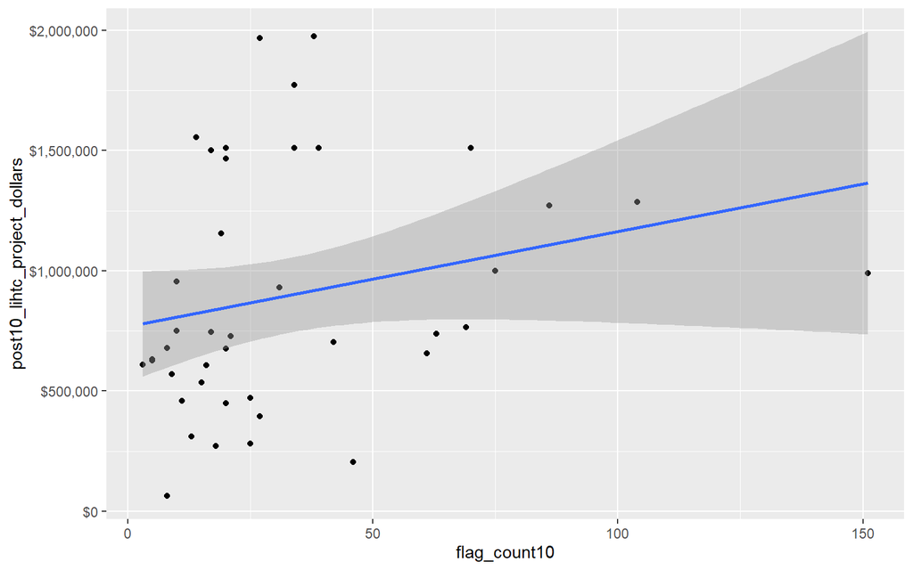

```r
# Cluster 1 Scatterplot
# y is our independent variable (LIHTC Project Dollars),
# x is our dependent variable (SVI flag count)

svi_divisional_county_lihtc_projects2 %>%
  filter(cluster == 1) %>%
  ggplot2::ggplot(aes(x=flag_count10,
                    y=post10_lihtc_project_dollars)) +
        geom_point() +
        geom_smooth(method="lm") +
        scale_y_continuous(labels = scales::dollar_format())
```

```r
svi_divisional_county_lihtc_projects2 %>%
  filter(cluster == 1) %>%
  select(flag_count10,post10_lihtc_project_dollars) %>%
  cor(method = "pearson")
```

```
##                              flag_count10 post10_lihtc_project_dollars
## flag_count10                    1.0000000                    0.2414151
## post10_lihtc_project_dollars    0.2414151                    1.0000000
```

Looking at our first and largest cluster, we can see that there is no strong correlation between the amount of flags and the amount of money spent.

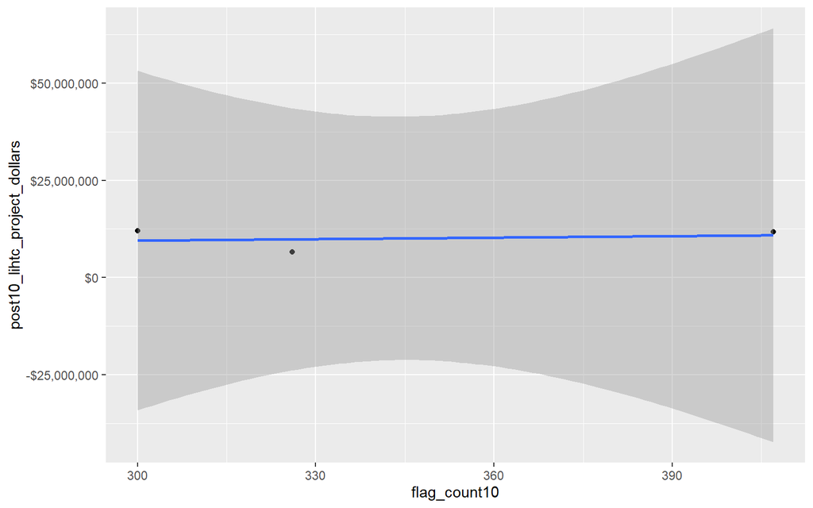

```r
# Cluster 2 Scatterplot
# y is our independent variable (LIHTC Project Dollars),
# x is our dependent variable (SVI flag count)

svi_divisional_county_lihtc_projects2 %>%
  filter(cluster == 2) %>%
  ggplot2::ggplot(aes(x=flag_count10,
                    y=post10_lihtc_project_dollars)) +
        geom_point() +
        geom_smooth(method="lm") +
        scale_y_continuous(labels = scales::dollar_format())
```

```r
svi_divisional_county_lihtc_projects2 %>%
  filter(cluster == 2) %>%
  select(flag_count10,post10_lihtc_project_dollars) %>%
  cor(method = "pearson")
```

```
##                              flag_count10 post10_lihtc_project_dollars
## flag_count10                    1.0000000                    0.2309379
## post10_lihtc_project_dollars    0.2309379                    1.0000000
```

Our number 2 cluster, which contains our largest outliers, confims this as well.

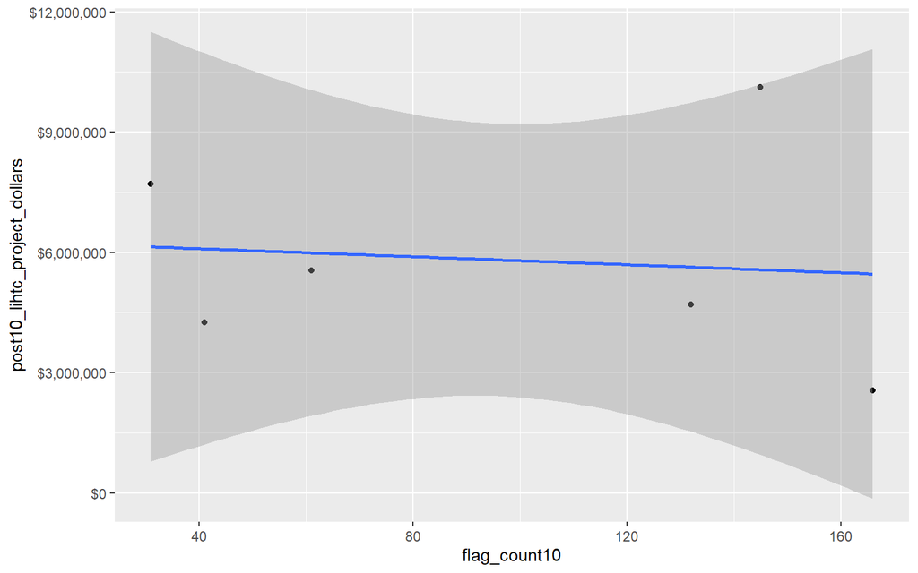

```r
# Cluster 3 Scatterplot
# y is our independent variable (LIHTC Project Dollars),
# x is our dependent variable (SVI flag count)

svi_divisional_county_lihtc_projects2 %>%
  filter(cluster == 3) %>%
  ggplot2::ggplot(aes(x=flag_count10,
                    y=post10_lihtc_project_dollars)) +
        geom_point() +
        geom_smooth(method="lm") +
        scale_y_continuous(labels = scales::dollar_format())
```

```r
svi_divisional_county_lihtc_projects2 %>%
  filter(cluster == 3) %>%
  select(flag_count10,post10_lihtc_project_dollars) %>%
  cor(method = "pearson")
```

```
##                              flag_count10 post10_lihtc_project_dollars
## flag_count10                    1.0000000                   -0.1082347
## post10_lihtc_project_dollars   -0.1082347                    1.0000000
```

Finally, our number three cluster shows a slight negative correlation, also confirming that there is not a strong relationship between the amount of money spent and the amount of flags.

```r
# Join our LIHTC projects data with our shapefile geocoordinates
svi_divisional_county_lihtc_sf <- left_join(svi_divisional_county_lihtc_projects, divisional_county_sf, join_by("FIPS_st" == "STATEFP", "FIPS_county" == "COUNTYFP"))

svi_divisional_county_lihtc_sf %>% head(5) %>% kbl() %>% kable_styling() %>% scroll_box(width = "100%")
```

| State | County | Division | post10_lihtc_project_cnt | tract_cnt | post10_lihtc_project_dollars | post10_lihtc_dollars_formatted | fips_county_st | FIPS_st | FIPS_county | state_name | region_number | region | division_number | flag_count10 | pop10 | flag_by_pop10 | flag_count_quantile10 | flag_pop_quantile10 | flag_count20 | pop20 | flag_by_pop20 | flag_count_quantile20 | flag_pop_quantile20 | county_name | geometry |
| --- | --- | --- | --- | --- | --- | --- | --- | --- | --- | --- | --- | --- | --- | --- | --- | --- | --- | --- | --- | --- | --- | --- | --- | --- | --- |
| DC | District of Columbia | South Atlantic Division | 21 | 53 | 11695555 | $11,695,555 | 11001 | 11 | 001 | District of Columbia | 3 | South Region | 5 | 407 | 157923 | 0.0025772 | 1 | 0.6 | 387 | 192201 | 0.0020135 | 1 | 0.4 | District of Columbia, DC | MULTIPOLYGON (((-76.95772 3… |
| FL | Broward County | South Atlantic Division | 3 | 17 | 2561000 | $2,561,000 | 12011 | 12 | 011 | Florida | 3 | South Region | 5 | 166 | 71933 | 0.0023077 | 1 | 0.6 | 160 | 84636 | 0.0018904 | 1 | 0.4 | Broward County, FL | MULTIPOLYGON (((-80.08484 2… |
| FL | Duval County | South Atlantic Division | 4 | 12 | 1286341 | $1,286,341 | 12031 | 12 | 031 | Florida | 3 | South Region | 5 | 104 | 40471 | 0.0025697 | 1 | 0.6 | 90 | 40771 | 0.0022075 | 1 | 0.6 | Duval County, FL | MULTIPOLYGON (((-81.39745 3… |
| FL | Escambia County | South Atlantic Division | 1 | 9 | 1510000 | $1,510,000 | 12033 | 12 | 033 | Florida | 3 | South Region | 5 | 70 | 30376 | 0.0023045 | 1 | 0.6 | 64 | 26675 | 0.0023993 | 1 | 0.6 | Escambia County, FL | MULTIPOLYGON (((-87.54197 3… |
| FL | Hillsborough County | South Atlantic Division | 7 | 17 | 10116734 | $10,116,734 | 12057 | 12 | 057 | Florida | 3 | South Region | 5 | 145 | 42317 | 0.0034265 | 1 | 0.8 | 149 | 50266 | 0.0029642 | 1 | 0.8 | Hillsborough County, FL | MULTIPOLYGON (((-82.75593 2… |

```r
# Create classes for bivariate mapping
svi_divisional_county_lihtc_sf <- bi_class(svi_divisional_county_lihtc_sf, x = flag_count10, y = post10_lihtc_project_dollars, style = "quantile", dim = 3)

# View data
svi_divisional_county_lihtc_sf %>% head(5) %>% kbl() %>% kable_styling() %>% scroll_box(width = "100%")
```

| State | County | Division | post10_lihtc_project_cnt | tract_cnt | post10_lihtc_project_dollars | post10_lihtc_dollars_formatted | fips_county_st | FIPS_st | FIPS_county | state_name | region_number | region | division_number | flag_count10 | pop10 | flag_by_pop10 | flag_count_quantile10 | flag_pop_quantile10 | flag_count20 | pop20 | flag_by_pop20 | flag_count_quantile20 | flag_pop_quantile20 | county_name | geometry | bi_class |
| --- | --- | --- | --- | --- | --- | --- | --- | --- | --- | --- | --- | --- | --- | --- | --- | --- | --- | --- | --- | --- | --- | --- | --- | --- | --- | --- |
| DC | District of Columbia | South Atlantic Division | 21 | 53 | 11695555 | $11,695,555 | 11001 | 11 | 001 | District of Columbia | 3 | South Region | 5 | 407 | 157923 | 0.0025772 | 1 | 0.6 | 387 | 192201 | 0.0020135 | 1 | 0.4 | District of Columbia, DC | MULTIPOLYGON (((-76.95772 3… | 3-3 |
| FL | Broward County | South Atlantic Division | 3 | 17 | 2561000 | $2,561,000 | 12011 | 12 | 011 | Florida | 3 | South Region | 5 | 166 | 71933 | 0.0023077 | 1 | 0.6 | 160 | 84636 | 0.0018904 | 1 | 0.4 | Broward County, FL | MULTIPOLYGON (((-80.08484 2… | 3-3 |
| FL | Duval County | South Atlantic Division | 4 | 12 | 1286341 | $1,286,341 | 12031 | 12 | 031 | Florida | 3 | South Region | 5 | 104 | 40471 | 0.0025697 | 1 | 0.6 | 90 | 40771 | 0.0022075 | 1 | 0.6 | Duval County, FL | MULTIPOLYGON (((-81.39745 3… | 3-2 |
| FL | Escambia County | South Atlantic Division | 1 | 9 | 1510000 | $1,510,000 | 12033 | 12 | 033 | Florida | 3 | South Region | 5 | 70 | 30376 | 0.0023045 | 1 | 0.6 | 64 | 26675 | 0.0023993 | 1 | 0.6 | Escambia County, FL | MULTIPOLYGON (((-87.54197 3… | 3-3 |
| FL | Hillsborough County | South Atlantic Division | 7 | 17 | 10116734 | $10,116,734 | 12057 | 12 | 057 | Florida | 3 | South Region | 5 | 145 | 42317 | 0.0034265 | 1 | 0.8 | 149 | 50266 | 0.0029642 | 1 | 0.8 | Hillsborough County, FL | MULTIPOLYGON (((-82.75593 2… | 3-3 |

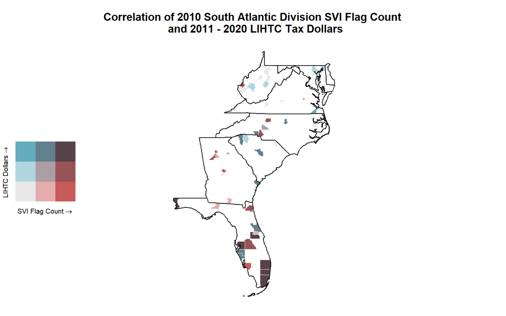

```r
# Create map with ggplot
svi_divisional_county_lihtc_map <- ggplot() +
  # Map county shapefile, fill with bi_class categories
  geom_sf(data = svi_divisional_county_lihtc_sf, mapping = aes(geometry=geometry, fill = bi_class), color = "white", size = 0.1, show.legend = FALSE) +
  # Set to biscale palette
  bi_scale_fill(pal = "GrPink", dim = 3) +
  # Add state shapefiles for outline
  geom_sf(data=divisional_st_sf, color="black", fill=NA, linewidth=.5, aes(geometry=geometry)) +
  labs(
    title = paste0("Correlation of 2010 ", census_division, " SVI Flag Count \n and 2011 - 2020 LIHTC Tax Dollars")
  ) +
  # Set them to biscale
  bi_theme(base_size = 10)

# Create biscale legend
svi_divisional_county_lihtc_legend <- bi_legend(pal = "GrPink",
                    dim = 3,
                    xlab = "SVI Flag Count",
                    ylab = "LIHTC Dollars",
                    size = 8)

# Combine map with legend using cowplot
svi_divisional_county_lihtc_bivarmap <- ggdraw() +
  draw_plot(svi_divisional_county_lihtc_map) +
  # Set legend location
  draw_plot(svi_divisional_county_lihtc_legend, x= -.02,  y = -.05,
 width=.20)


# View map
svi_divisional_county_lihtc_bivarmap
```

It appears that this time, the majority of high flags are still in Florida; there is no significant impact on the map in our other states, though there is a slight increase in spending without high flag counts above North Carolina.

```r
svi_divisional_county_lihtc_sf %>% filter(State == "FL") %>% select(State, County, flag_count10, post10_lihtc_dollars_formatted) %>% arrange(desc(flag_count10)) %>% head(6)
```

```
##   State              County flag_count10 post10_lihtc_dollars_formatted
## 1    FL   Miami-Dade County          300                    $12,039,478
## 2    FL      Broward County          166                     $2,561,000
## 3    FL Hillsborough County          145                    $10,116,734
## 4    FL   Palm Beach County          132                     $4,702,545
## 5    FL        Duval County          104                     $1,286,341
## 6    FL         Polk County           86                     $1,271,000
```

```r
saveRDS(svi_divisional_lihtc, file = here::here(paste0("data/wrangling/", str_replace_all(census_division, " ", "_"), "_svi_divisional_lihtc.rds")))

saveRDS(svi_national_lihtc, file = here::here(paste0("data/wrangling/", str_replace_all(census_division, " ", "_"), "_svi_national_lihtc.rds")))

saveRDS(svi_divisional_nmtc, file = here::here(paste0("data/wrangling/", str_replace_all(census_division, " ", "_"), "_svi_divisional_nmtc.rds")))

saveRDS(svi_national_nmtc, file = here::here(paste0("data/wrangling/", str_replace_all(census_division, " ", "_"), "_svi_national_nmtc.rds")))
```